# Dealing with Class Imbalances and Unsupervised Learning with Text

11/20/2019

## Dealing with class imbalances

- In machine learning it is common to have slightly imbalanced samples.
- For example:
  - May have 40% of “negative” movie reviews, 60% of “positive” reviews.
  - May have 15% of “viral” tweets and 85% of “non-viral” tweets.

## This can become a serious problem with rare events in political science

- Predictions with rare classes can pose big problems for training machine learning algorithms.
  - eg) predicting civil wars, election anomalies etc.
- This is because the classifier simply does not get enough information from a positive or negative class.
- As a result performance suffers greatly.
- Luckily, there are ways that we can effectively deal with this.

## Dealing with class imbalances

- *Undersampling* - randomly remove observations from the class with a lot of observations.
- *Oversampling* - randomly increase the number of observations in the class with fewer observations by sampling. This will result in copies being included in the sample.
- *Synthetic sampling (SMOTE)* - Synthetically manufacture observations in the class with fewer observations using nearest neighbors classificaiton.
- Choice of method depends upon two things:
  - Population considerations.
  - Performance.

## Population considerations

- If you choose any of these methods to train your algorithms, it will affect the population that you are training your data on.
- Let’s take a civil war example where out of 10,000 documented military conflicts only 1% of those (100) are civil wars.
- *Your goal*: What you would like to do is to predict the factors that relate to civil war.
- Using a 30/70 split, you have 70 civil wars in your training data and 7,000 non-civil wars.
- *Question*: Should you resample before or after splitting the training and validation data? Why?

## Answer

- You should resample AFTER dividing your training and test data.
- ONLY resample on your training data!
- Validation data should NOT BE RESAMPLED!

## Population considerations: oversampling

- This would require resampling the 70 observations until you got about 6930 or so civil wars included.
- Lots of duplication.

## Population considerations: synthetic sampling

- Synthetic sampling would create synthetic cases using nearest neighbors.
- Most of your civil war data would be synthetic.

## Unsupervised Learning with Text

- In general, the purpose of unsupervised learning is *dimensionality reduction*
- Discovery of latent dimensions given some data.
- Examples) K-means clustering, principal components analysis, multidimensional scaling, EM algorithm.

## K-means clustering

- K-means clustering iteratively finds “groupings” of data using random intialization of clusters.
- Applications: discovering latent groupings from data (ideological viewpoints, etc), learning features from images etc.
- Closely related to EM algorithm which will be discussed later.

## Principal components analysis

- Uses matrix factorization to extract top “factors” that explain the most variance in the data.
- Applications - construction of latent dimensions from a large group of items (eg psychometrics)

## Multidimensional Scaling

- Multidimensional scaling via the NOMINATE procedure, short for “Nominal Three-Step Estimation” is similar to PCA and functions as a means of collapsing large matrices of vote data into two left right dimensions.

## Unsupervised learning for text data

- In general, we are interested in learning about latent similarities between documents.
- Applications: are the issues that presidents write executive orders for different? do experimental treatments change the issues discussed in open ended surveys? how are speeches by Republicans and Democrats different?

## Unsupervised learning methods for text data

- **Latent semantic analysis** - uses singular value decomposition (linera algebra) to measure similarity between documents.
- **K-means clustering** - uses K-Means algorithm to measure similarity between documents.
- **Topic modeling** - uses nonparametric Bayesian model to measure similarity between documents and measure topics.

## Topic models: Motivation

- What are the topics that a document is about?
- Given one document, can we find other documents about the same topics?
- How do topics change over time?
- Flavors of topic models: correlated topic models, structural topic models, dynamic topic models, semi-supervised topic models.

## Nonparametric Bayesian modeling

- Topic models are **generative** which means that they model texts as if they were generated from a certain probability distribution.

-Each document defines a distribution over (hidden) topics.

-Assume each topic defines a distribution over words.

-The posterior probability of latent variables given a corpus determines the collection into topics

## The generative model

- \(D = \{d_{1},\cdots,d_{n}\}\) documents contain a vocabulary of \(V = \{v_{1},\cdots,v_{w}\}\) terms.
- Assume \(K\) topics (pre-specified).
- Each document has \(K\)-dimensional multinomial \(\theta_{d}\) over topics with a common Dirichlet prior \(Dir(\alpha)\)
- Each topic has a \(V\)-dimensional multinomial \(\beta_{k}\) over words with a common symmetric Dirichlet prior \(D(\eta)\).

## What does a Dirichlet look like?

- Dirichlet expresses probabilities on an N-dimensional simplex.
- Parameters are vectors of length K or V, respectively such that: \(\alpha,\eta \in \mathbb{R}^+\)

## Generative process

For each **topic** \(1 \cdots k\): 1. Multinomial over words \(\beta_{k} \sim Dir(\eta)\)

For each **document** \(1\cdots d\):

1. Multinomial over topics \(\theta_{d} \sim Dir(\alpha)\)

2 For each word \(w_{d,n}\): a. Draw topic \(Z_{d,n}\sim Mult(\theta_{d})\) with \(Z_{d,n}\in [1..K]\) b. Draw a word \(w_{d,n}\sim Mult(Z_{d,n})\)

## Inference problem

\[ \displaystyle P(\theta, z,\beta| w,\alpha,\eta) = \frac{P(\theta, z, \beta ; w,\alpha,\eta)}{\int\int \sum P(\theta,z,\beta, w,\alpha,\eta)} \] - Cannot do integral in the denominator

- Need to use approx. inference (1) Gibbs sampling ; (2) variational inference

## Quantiaties we need to calculate

- Gibbs sampling aside, as Bayesians we need to calculate expected values of the parameters given the data.

**Topic probability** of word *v* according to topic *k*: \[\bar{\beta}_{k,v} = E[\beta_{k,v}|w_{1:D,1:N}] \] **Topic proportions of each document** *d*: \[\bar{z}_{d,n,k} = E[Z_{d,n} = k|w_{1:D,1:N}] \]

**Topic assignment of each word** \(w_{d,n}\): \[\bar{\theta}_{k,v} = E[\theta_{d,k}|w_{1:D,1:N}] \]

## Topic modeling in R

```r
library(topicmodels)

data("AssociatedPress")
AssociatedPress
```

```
## <<DocumentTermMatrix (documents: 2246, terms: 10473)>>
## Non-/sparse entries: 302031/23220327
## Sparsity           : 99%
## Maximal term length: 18
## Weighting          : term frequency (tf)
```

- Load the “topicmodels” package.
- Load the “AssociatedPress” corpus.

## Estimating a topic model with 5 topics

```r
# set a seed so that the output of the model is predictable
ap_lda <- LDA(AssociatedPress, k = 5, control = list(seed = 1234))
ap_lda
```

```
## A LDA_VEM topic model with 5 topics.
```

## What are the topics for this model?

```r
terms(ap_lda, k=10) # top 10 words for each topic
```

```
##       Topic 1      Topic 2      Topic 3   Topic 4  Topic 5
##  [1,] "percent"    "bush"       "million" "i"      "government"
##  [2,] "year"       "soviet"     "new"     "people" "police"
##  [3,] "million"    "president"  "company" "two"    "court"
##  [4,] "billion"    "i"          "market"  "police" "people"
##  [5,] "new"        "united"     "stock"   "years"  "two"
##  [6,] "report"     "states"     "billion" "new"    "state"
##  [7,] "last"       "new"        "percent" "three"  "case"
##  [8,] "years"      "house"      "year"    "city"   "years"
##  [9,] "workers"    "dukakis"    "york"    "like"   "south"
## [10,] "department" "government" "dollar"  "school" "attorney"
```

## Let’s find the topic distributions for each document

```r
posterior_inference <- posterior(ap_lda)
posterior_topic_dist<-posterior_inference$topics # This is the distribution of topics for each document
posterior_topic_dist[1:10,]
```

```
##                  1            2            3            4            5
##  [1,] 0.0002931866 0.0002931860 0.0002931868 0.9988272506 0.0002931900
##  [2,] 0.2160562899 0.5291368426 0.1648278335 0.0002845466 0.0896944874
##  [3,] 0.0003023722 0.0003023708 0.0003023724 0.9987905120 0.0003023726
##  [4,] 0.0003723573 0.3157917595 0.1293150516 0.5178920109 0.0366288207
##  [5,] 0.0011632293 0.0011632205 0.0011632275 0.9953471053 0.0011632175
##  [6,] 0.0001832567 0.9710640667 0.0001832558 0.0001832561 0.0283861647
##  [7,] 0.7280965515 0.0345892983 0.0169448050 0.0004613390 0.2199080061
##  [8,] 0.0547309513 0.9410863495 0.0013942339 0.0013942320 0.0013942333
##  [9,] 0.2534383726 0.2483335805 0.0104549136 0.4773181676 0.0104549657
## [10,] 0.0675643091 0.3423602072 0.0006634951 0.0896826050 0.4997293835
```

## Topic distribution for documents 1-3

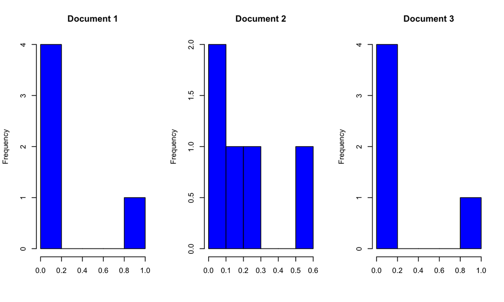

```r
par(mfrow=c(1,3))
hist(posterior_topic_dist[1,], col="blue",main="Document 1", xlab = "")
hist(posterior_topic_dist[2,], col="blue",main="Document 2", xlab = "")
hist(posterior_topic_dist[3,], col="blue",main="Document 3", xlab = "")
```

## Let’s measure topic similarity between document 1 and documents 2 and 3

```r
doc_similarity<-function(doc1,doc2){
  sim<-sum(
    (sqrt(doc1) + sqrt(doc2))^2
  )
  return(sim)
}
```

```r
doc_similarity(posterior_topic_dist[1,],posterior_topic_dist[2,]) # Documents 1 and 2
```

```
## [1] 2.098705
```

```r
doc_similarity(posterior_topic_dist[1,],posterior_topic_dist[3,]) # Documents 1 and 3
```

```
## [1] 4
```

## Estimating a topic model with 10 topics

```r
ap_lda10<- LDA(AssociatedPress,
              k = 10, control = list(seed = 1234))
ap_lda10
```

```
## A LDA_VEM topic model with 10 topics.
```

## What are the topics for this model?

```r
terms(ap_lda10, k=5)
```

```
##      Topic 1   Topic 2     Topic 3   Topic 4     Topic 5      Topic 6
## [1,] "percent" "bush"      "million" "police"    "government" "police"
## [2,] "market"  "states"    "company" "military"  "party"      "people"
## [3,] "prices"  "house"     "billion" "two"       "people"     "i"
## [4,] "year"    "president" "year"    "people"    "political"  "two"
## [5,] "new"     "united"    "new"     "officials" "south"      "city"
##      Topic 7      Topic 8     Topic 9 Topic 10
## [1,] "office"     "i"         "court" "soviet"
## [2,] "department" "dukakis"   "case"  "west"
## [3,] "new"        "bush"      "judge" "east"
## [4,] "federal"    "new"       "drug"  "united"
## [5,] "students"   "president" "trial" "german"
```

## Let’s find the topic distributions for each document

```r
posterior_inference <- posterior(ap_lda10)
posterior_topic_dist<-posterior_inference$topics # This is the distribution of topics for each document
posterior_topic_dist[1:5,]
```

```
##                 1            2            3            4            5
## [1,] 0.0001581762 0.0001581762 0.0001581762 0.0001581762 0.0001581762
## [2,] 0.0001535139 0.0001535139 0.1244737612 0.0862032618 0.0001535139
## [3,] 0.0001631305 0.0001631305 0.0001631305 0.0001631305 0.0001631305
## [4,] 0.0978437302 0.0002008818 0.0002008818 0.2879816360 0.0002008818
## [5,] 0.0006273462 0.0006273462 0.0006273462 0.0006273462 0.0006273462
##                 6            7            8            9           10
## [1,] 0.9985764145 0.0001581762 0.0001581762 0.0001581762 0.0001581762
## [2,] 0.0001535139 0.4394241118 0.0001535139 0.0001535139 0.3489777816
## [3,] 0.9985318258 0.0001631305 0.0001631305 0.0001631305 0.0001631305
## [4,] 0.0002008818 0.0002008818 0.4639246750 0.0582031535 0.0910423961
## [5,] 0.0006273462 0.0006273462 0.9943538845 0.0006273462 0.0006273462
```

## Topic distribution for documents 1-3

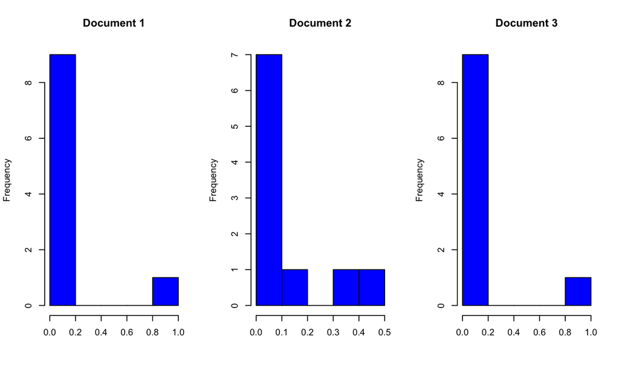

```r
par(mfrow=c(1,3))
hist(posterior_topic_dist[1,], col="blue",main="Document 1", xlab = "")
hist(posterior_topic_dist[2,], col="blue",main="Document 2", xlab = "")
hist(posterior_topic_dist[3,], col="blue",main="Document 3", xlab = "")
```

## Let’s measure topic similarity between document 1 and documents 2 and 3

```r
doc_similarity<-function(doc1,doc2){
  sim<-sum(
    (sqrt(doc1) + sqrt(doc2))^2
  )
  return(sim)
}
```

```r
doc_similarity(posterior_topic_dist[1,],posterior_topic_dist[2,]) # Documents 1 and 2
```

```
## [1] 2.074114
```

```r
doc_similarity(posterior_topic_dist[1,],posterior_topic_dist[3,]) # Documents 1 and 3
```

```
## [1] 4
```

## Model selection

- How do we choose between estimating a 5, 10, 15, 20 or 50 topic model?
- Most methods for model selection don’t perform that well, but the one that is typically used and available in softward packages is **perplexity**.
- With unlabled data density estimation can be used to assess models.

## Perplexity

- Comes from information theory
- Measure of how well a probability distribution or probability model predicts a sample.
- Low perplexity \(=\) probability model does a better job.
- Directly related to entropy

## Perplexity

\[ perplexity(D_{test}) = \exp\left{ -\frac{\sum log(p(w_{d}))}{\sum N_{d}} \right} \]

## Perplexity

```r
perplexity(ap_lda)
```

```
## [1] 2959.981
```

```r
perplexity(ap_lda10)
```

```
## [1] 2441.874
```